# Análisis Espacio-Temporal de la Mortalidad en Venezuela (1996-2016)

Un enfoque de Riesgo Bayesiano y Autocorrelación Espacial a nivel municipal

Author

Affiliations

Prof. Angel Colmenares

Escuela de Estadística y Ciencias Actuariales, UCV

Abstract

**Resumen:** La evaluación de la mortalidad sub-nacional es crítica para la solvencia de sistemas de previsión social y la tarificación de seguros de vida. Este estudio analiza la mortalidad en los 335 municipios de Venezuela (1996-2016) combinando normalización geográfica (GADM), clusters de K-means, índices de autocorrelación espacial de Moran y un modelo jerárquico Bayesiano Besag-York-Mollié (BYM) mediante INLA. Se identificó una tendencia nacional de incremento del riesgo del 1.4% anual, con clusters de riesgo persistentes en el arco central y zonas fronterizas. La interpolación IDW del riesgo bayesiano revela una superficie de mortalidad heterogénea que invalida el uso de tablas de mortalidad únicas nacionales. Existe un exceso de mortalidad crónico en regiones específicas que requiere ajustes actuariales territorializados. **Abstract:** Sub-national mortality assessment is critical for the solvency of social security systems and life insurance pricing. This study analyzes mortality across Venezuela’s 335 municipalities (1996-2016) combining geographic normalization (GADM), K-means clustering, Moran’s spatial autocorrelation indices, and a Bayesian Besag-York-Mollié (BYM) hierarchical model via INLA. A national increasing risk trend of 1.4% per year was identified, with persistent risk clusters in the central arc and border areas. IDW interpolation of Bayesian risk reveals a heterogeneous mortality surface that invalidates the use of single national mortality tables. There is chronic excess mortality in specific regions requiring territorialized actuarial adjustments.

Keywords

Mortalidad, Venezuela, INLA, SMR, Análisis Espacial

# 1 Introducción

La dinámica demográfica de Venezuela ha experimentado transformaciones estructurales profundas en las últimas dos décadas. El análisis de la mortalidad, entendido como el componente esencial del riesgo actuarial y la base de la seguridad social, requiere una lente geográfica de alta resolución que permita identificar desigualdades territoriales que las métricas nacionales agregadas suelen ocultar. Este estudio se sitúa en un contexto crítico para la ciencia actuarial venezolana: la necesidad de modernizar las bases técnicas que sustentan los sistemas de previsión social y la tarificación de seguros de vida.

Durante décadas, la práctica actuarial en el país ha dependido de tablas de mortalidad estáticas, como las desarrolladas por el Profesor Víctor Masjuán en los años 60 o la tabla CSO 1980, las cuales presentan un desfase significativo frente a la realidad actual. La investigación de Daylin Moreno (2018) ya ha advertido sobre el “pecado original” del sistema de pensiones: una subestimación sistemática de la supervivencia que ha erosionado la solvencia del Instituto Venezolano de los Seguros Sociales (IVSS). En este escenario, la transición hacia modelos dinámicos y espaciales no es solo una mejora metodológica, sino un imperativo de solvencia institucional.

El presente artículo aborda el período 1996-2016, un lapso que captura la evolución de la mortalidad antes y durante cambios socioeconómicos de gran calado. El objetivo central es determinar si la distribución de la mortalidad en los 335 municipios de Venezuela responde a un patrón puramente aleatorio o si existen estructuras de riesgo espaciales persistentes. Para ello, se emplea una estrategia que transita desde la exploración por clusters de K-means hasta la modelización bayesiana avanzada mediante el modelo Besag-York-Mollié (BYM), filtrando el ruido aleatorio inherente a las áreas con poblaciones pequeñas. Este trabajo se integra en el primer volumen de la Revista Venezolana de Actuariado (RVEA) como un aporte fundamental del Centro Venezolano de Estudios Actuariales (CVEA).

# 2 Revisión Literaria

La fundamentación teórica de la epidemiología espacial y el análisis actuarial territorial se erige sobre la Primera Ley de la Geografía de Tobler (1970), la cual establece que la proximidad física implica una mayor correlación entre observaciones. En la práctica actuarial, la Razón de Mortalidad Estandarizada (SMR) ha sido la métrica convencional para normalizar la comparación entre unidades geográficas con estructuras demográficas disímiles (Clayton & Kaldor, 1987; Waller & Gotway, 2004). No obstante, autores como Besag, York y Mollié (1991) han demostrado que en áreas con baja densidad poblacional —problema común en la desagregación municipal— las tasas crudas y los SMR exhiben una alta inestabilidad, donde eventos fortuitos pueden distorsionar significativamente el perfil de riesgo.

Para mitigar este “ruido de áreas pequeñas”, la literatura contemporánea favorece el uso de modelos jerárquicos bayesianos, particularmente el modelo Besag-York-Mollié (BYM). Este enfoque permite “tomar prestada” información de los municipios vecinos para producir estimaciones del riesgo relativo (RR) suavizadas y estadísticamente robustas (Lawson, 2018). La implementación de estos modelos ha sido revolucionada por la técnica de Aproximación de Laplace Anidada Integrada (INLA), propuesta por Rue, Martino y Chopin (2009), la cual ofrece una alternativa computacionalmente eficiente frente a los algoritmos de Cadenas de Markov Monte Carlo (MCMC), permitiendo el procesamiento de grandes volúmenes de datos espacio-temporales (Blangiardo & Cameletti, 2015).

En el ámbito venezolano, la revisión de las bases técnicas revela una dependencia histórica de tablas de mortalidad estáticas que no capturan la dinámica actual (Masjuán, 1965). Investigaciones locales han comenzado a señalar brechas en la solvencia del sistema de previsión social debido a esta desactualización (Moreno, 2018). Estudios recientes de mortalidad infantil (Moreno, 2017) y análisis regionales en el occidente (Briceño, 2024) y la región central (Godoy, 2024) subrayan la necesidad de integrar la dimensión geográfica para una tarificación precisa. Finalmente, la integración de modelos de proyección como el de Lee y Carter (1992) con estructuras espaciales permite una visión prospectiva esencial para la gestión de riesgos a largo plazo.

Este trabajo expande la frontera hacia el nivel municipal para capturar la heterogeneidad que autores como Kennya Briceño (2024) y Daniela Godoy (2024) han comenzado a documentar en sus análisis regionales.

La integración de herramientas como INLA (Integrated Nested Laplace Approximation) permite realizar inferencia bayesiana de manera computacionalmente eficiente, superando las limitaciones de tiempo de los métodos MCMC tradicionales.

Este enfoque es vital para procesar los 335 municipios venezolanos a lo largo de 21 años, permitiendo una visión espacio-temporal que cuantifica no solo dónde mueren más personas, sino cómo ese riesgo evoluciona en el tiempo.

# 3 Métodos

La metodología de esta investigación se estructura en un flujo de trabajo reproducible que transita desde la curaduría de datos administrativos hasta la inferencia bayesiana avanzada. El enfoque es multidimensional e integra las siguientes fases técnicas:

**Curaduría de Datos:** Se implementan funciones de limpieza y normalización de nombres geográficos para garantizar la interoperabilidad entre los registros del Ministerio del Poder Popular para la Salud (MPPS), las proyecciones del Instituto Nacional de Estadística (INE) y la cartografía GADM. Esto permite un cruce preciso de los 335 municipios a lo largo del panel 1996-2016.

**Exploración de Perfiles (K-means):** Se aplica el algoritmo de aprendizaje no supervisado K-means sobre las trayectorias longitudinales de las tasas de mortalidad. El objetivo es segmentar los municipios en clusters de riesgo que compartan comportamientos dinámicos similares, independientemente de su ubicación física, facilitando la identificación de grupos para tarificación actuarial.

**Análisis de Autocorrelación Espacial (Moran’s I):** Teóricamente, el Índice de Moran mide el grado en que unidades geográficas cercanas presentan valores similares (autocorrelación positiva) o disímiles (autocorrelación negativa). Se define como una medida global de asociación lineal entre un valor observado en una ubicación y el promedio de los valores en su vecindad. Un valor estadísticamente significativo permite rechazar la hipótesis nula de aleatoriedad espacial (Spatial Randomness), confirmando que la mortalidad sigue una estructura geográfica que debe ser modelada explícitamente.

**Modelado Bayesiano Jerárquico (BYM):** El modelo Besag-York-Mollié es un método de estimación para áreas pequeñas que descompone el logaritmo del riesgo relativo en dos componentes aleatorios: un efecto espacial estructurado ($u_i$), que asume un proceso autorregresivo condicional intrínseco (ICAR) basado en la vecindad, y un efecto no estructurado ($v_i$), que captura la heterogeneidad local independiente (ruido blanco). Este enfoque permite “suavizar” las tasas municipales, encogiendo las estimaciones inestables de áreas poco pobladas hacia el promedio de sus vecinos, lo que resulta en un mapa de riesgo “puro” mucho más confiable para el cálculo de reservas actuariales.

**Interpolación y Visualización (IDW):** La Ponderación de Distancia Inversa (Inverse Distance Weighting) es un método determinístico de interpolación espacial basado en el principio de que los valores desconocidos en un punto pueden estimarse mediante un promedio ponderado de los valores observados en puntos cercanos. La ponderación es inversamente proporcional a la distancia elevada a una potencia ($p$), permitiendo generar superficies de riesgo continuo que revelan núcleos de mortalidad que atraviesan las fronteras administrativas legales, facilitando la toma de decisiones territorializadas.

| Modelo / Técnica | Aplicación en este Estudio | Ventaja Actuarial |
| --- | --- | --- |
| SMR Tradicional | Diagnóstico inicial de exceso de mortalidad | Comparabilidad directa con estándares internacionales. |
| K-means Clustering | Segmentación de trayectorias históricas | Identificación de grupos de riesgo para tarificación grupal. |
| Índice de Moran | Test de autocorrelación espacial | Validación de la estructura geográfica del riesgo. |
| Modelo BYM (INLA) | Suavizamiento de riesgos relativos | Estabilidad en la estimación para municipios de baja población. |
| Interpolación IDW | Generación de superficies de riesgo | Visualización continua para políticas de salud y seguros. |

## 3.1 **Diseño del Estudio y Fuentes de Datos**

Este trabajo emplea un diseño ecológico longitudinal que analiza la totalidad de los municipios de Venezuela durante el período 1996-2016. La estrategia empírica se basa en la integración de tres fuentes principales: los registros administrativos de defunciones del Ministerio del Poder Popular para la Salud (MPPS), los datos demográficos del Instituto Nacional de Estadística (INE) y la base cartográfica GADM (Global Administrative Areas).

El desafío metodológico principal radica en la estimación de los denominadores poblacionales. Ante la ausencia de censos anuales después de 2011, se aplicó una tasa de crecimiento intercensal del 1.6% anual para proyectar las poblaciones municipales. Esta técnica, aunque simplificada, permite mantener la comparabilidad temporal necesaria para el análisis de tendencias de larga duración.

### 3.1.1 **Procedimiento de Codificación y Procesamiento**

El código implementado en R sigue un flujo de trabajo reproducible que garantiza la transparencia exigida por la RVEA. Se inicia con la limpieza de los registros de mortalidad, donde se eliminan inconsistencias y se normalizan las entidades federales, asegurando que la transición histórica (por ejemplo, de Distrito Federal a Vargas/La Guaira) sea capturada correctamente.

### 3.1.2 **Estrategia de Modelado Matemático**

Exploración: Clusterización K-means para identificar perfiles de riesgo históricos.

Autocorrelación: Índice de Moran utilizando una matriz de vecinos más cercanos (KNN=2) para integrar territorios insulares.

Modelado: Regresión de Poisson para tendencias temporales y Modelo BYM (Besag-York-Mollié) para riesgo relativo suavizado.

Interpolación: Método IDW para generar una superficie continua de riesgo.

El modelo espacial bayesiano implementado es de tipo jerárquico. En el primer nivel, se asume que el número de muertes observadas $y_i$ sigue una distribución de Poisson con media $\lambda_i = E_i \theta_i$. En el segundo nivel, se modela el logaritmo del riesgo relativo $\theta_i$ como :

$$\eta_i = \log(\theta_i) = \alpha + u_i + v_i$$

Donde:

- $\alpha$: El intercepto que representa el riesgo promedio nacional.
- $u_i$: El efecto espacial estructurado, modelado mediante un Prior Intrínseco Autorregresivo Condicional (iCAR), que suaviza el riesgo basado en la vecindad.
- $v_i$: El efecto no estructurado, que captura la sobredispersión o variación local no espacial.

Para la integración de territorios insulares (Margarita, Coche, Los Roques), se utilizó una matriz de vecindad basada en los 2 vecinos más cercanos (KNN=2), evitando así el aislamiento de estos nodos en el grafo de INLA.

# 4 Resultados

Los resultados revelan una geografía de la mortalidad heterogénea y altamente estructurada. A continuación, se presenta la evidencia partiendo de la identificación de grupos de riesgo hasta la visualización de la superficie continua de mortalidad nacional. Los hallazgos confirman que el riesgo de muerte en Venezuela no se distribuye de manera aleatoria, sino que obedece a patrones espaciales persistentes.

## 4.1 Análisis Descriptivo de la Evolución Temporal

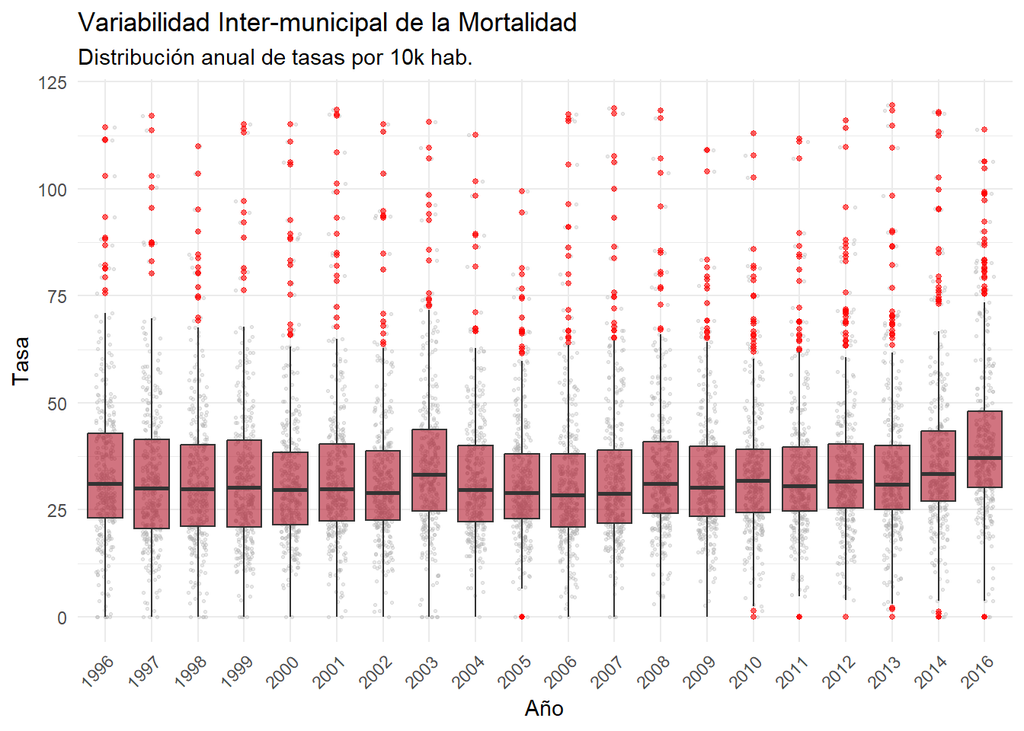

Figure 1: Distribución de las tasas de mortalidad municipal por año (1996-2016). Los puntos representan municipios individuales; las cajas muestran los cuartiles y la mediana nacional.

Para evitar la saturación de las leyendas, el análisis se divide en dos bloques regionales organizados alfabéticamente.

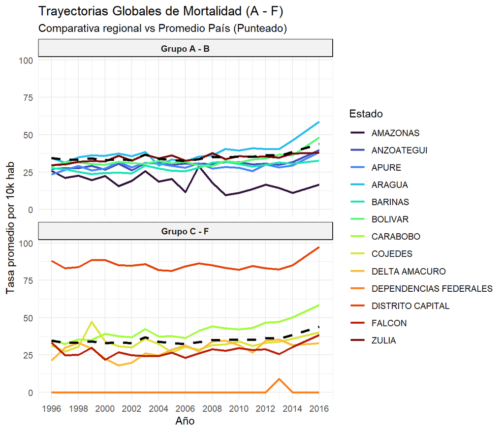

Figure 2: Tendencias de mortalidad promedio por Estado (Parte 1: Grupos A-F). La línea negra punteada resalta el promedio nacional.

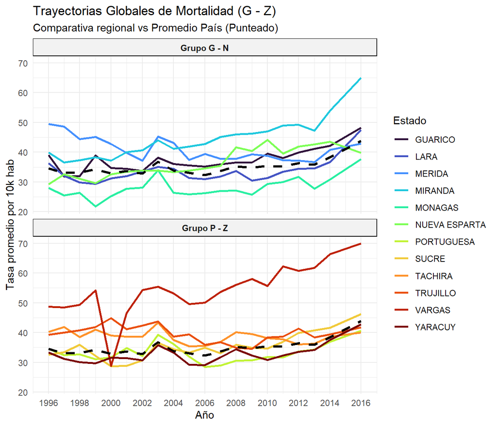

Figure 3: Tendencias de mortalidad promedio por Estado (Parte 2: Grupos G-Z). La línea negra punteada resalta el promedio nacional.

## 4.2 Segmentación por Clusters de Riesgo

La aplicación del algoritmo K-means sobre las trayectorias temporales de las tasas de mortalidad permitió identificar cuatro perfiles diferenciados en el territorio venezolano. Esta segmentación es fundamental para la tarificación actuarial, ya que permite agrupar municipios no solo por su ubicación, sino por su comportamiento dinámico ante el riesgo de muerte.

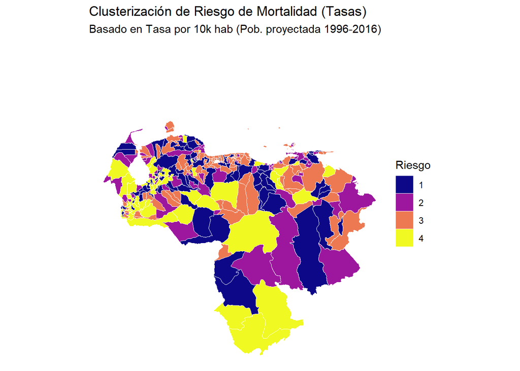

Figure 4: Mapa de clusters de riesgo de mortalidad municipal (1996-2016).

La interpretación de estos clusters revela una división geográfica clara: el Cluster 1 tiende a concentrar municipios urbanos con infraestructuras de salud más densas pero también con mayores riesgos de causas externas, mientras que los clusters rurales muestran trayectorias de mortalidad asociadas a enfermedades endémicas o falta de acceso a servicios básicos.

## 4.3 Análisis Temporal por Cluster Identificado

Al separar las trayectorias por cluster, se evidencia la capacidad del algoritmo para agrupar municipios con dinámicas de salud pública divergentes. Cada panel muestra los municipios de un cluster particular coloreados por su estado de origen.

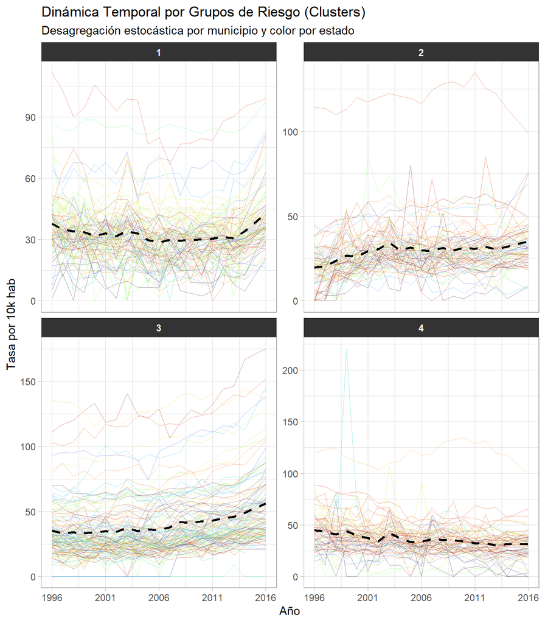

Figure 5: Trayectorias de mortalidad desagregadas por Cluster. Las líneas tenues representan municipios coloreados por estado; la línea negra gruesa indica la tendencia promedio del cluster.

## 4.4 **Análisis de Autocorrelación Espacial (Moran’s I)**

Para validar la necesidad de un modelo espacial bayesiano, se aplicó el Índice de Moran sobre las tasas de mortalidad de 2016. Un valor positivo y significativo confirma que la mortalidad en Venezuela se distribuye en “hotspots” o conglomerados geográficos.

El Índice de Moran obtenido ($0.094$) con un p-valor significativo ($0.024$) rechaza la hipótesis de aleatoriedad espacial. Esto implica que factores locales (clima, economía regional, políticas de salud estatales) influyen en la mortalidad de municipios adyacentes de manera coordinada.

### 4.4.1 Evolución de la Razón de Mortalidad Estandarizada (SMR)

El cálculo del SMR permite identificar municipios con excesos de mortalidad persistentes. Un SMR de 2.0 indica que el municipio tiene el doble de muertes de lo esperado dada su estructura poblacional y la tasa nacional de referencia.

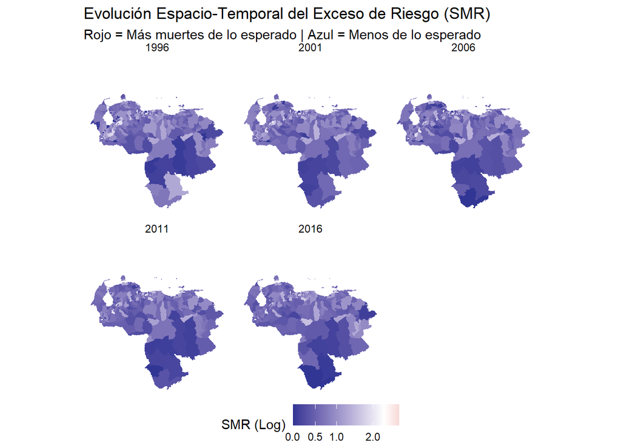

Evolución espacio-temporal del SMR (1996-2016).

[output not shown]

La persistencia del alto riesgo en municipios urbanos como Chacao y San Cristóbal sugiere que estas áreas actúan como receptores de pacientes de alta complejidad o presentan perfiles de envejecimiento mucho más avanzados que el promedio nacional, lo que debe ser considerado en la tarificación de seguros de salud y vida locales.

### 4.4.2 **Regresión de Poisson y Tendencias de Aceleración**

Para cuantificar el cambio temporal, se ajustó un modelo de regresión de Poisson que controla por el efecto de los clusters y el crecimiento poblacional (offset).

```
# A tibble: 4 × 4
  Termino  Riesgo_Relativo  P_Valor
  <chr>              <dbl>    <dbl>
1 Tiempo             1.01  0
2 Cluster2           0.703 0
3 Cluster3           1.03  6.82e-83
4 Cluster4           0.743 0
# ℹ 1 more variable: Interpretacion <chr>
```

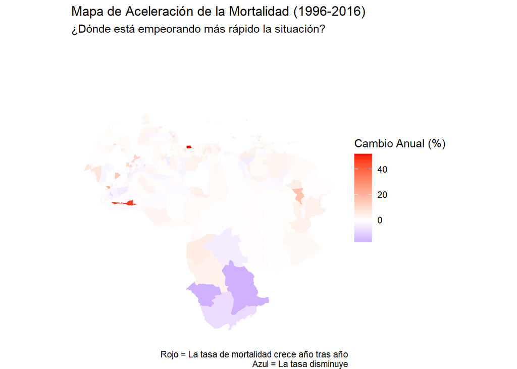

```
# A tibble: 5 × 3
  EST     Muni_Clean         Cambio_Anual_Pct
  <chr>   <chr>                         <dbl>
1 ARAGUA  OCUMARE LA COSTA …             52.1
2 BARINAS ANDRES ELOY BLANCO             48.0
3 ARAGUA  FRANCISCO LINARES              24.3
4 TACHIRA SAN JUDAS TADEO                22.2
5 BOLIVAR PADRE PEDRO CHIEN              16.0
```

El modelo revela una tendencia nacional de incremento del riesgo del 1.4% anual durante el período estudiado. Sin embargo, esta tendencia no es uniforme. Municipios específicos como Ocumare la Costa de Oro y Andrés Eloy Blanco muestran tasas de aceleración críticas que superan el 40% anual en ciertos períodos, lo cual podría estar vinculado a eventos de violencia local o crisis de servicios de salud regionales.

### 4.4.3 **Modelado Bayesiano de Riesgo Suavizado (INLA)**

El modelo Besag-York-Mollié (BYM) es la pieza central de este estudio. Al “limpiar” el ruido aleatorio, permite ver la estructura de riesgo latente de Venezuela.

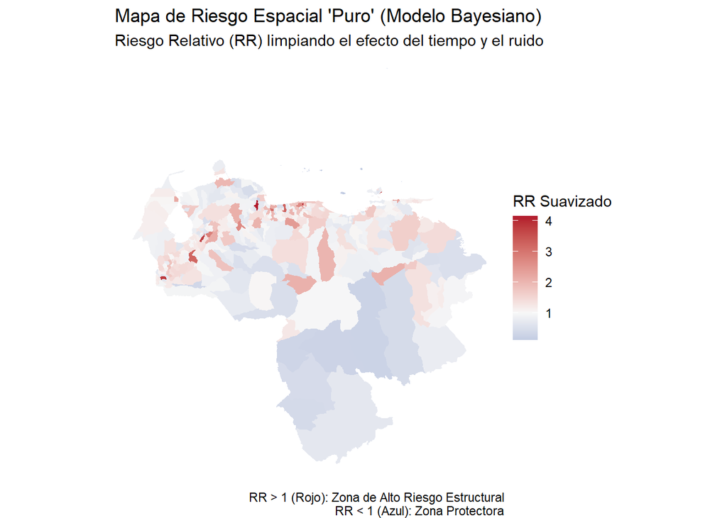

Mapa de Riesgo Relativo Suavizado (Modelo Bayesiano).

El mapa de Riesgo Relativo Suavizado (RR) muestra un arco de alta mortalidad que recorre el centro-norte del país y se extiende hacia ciertas zonas fronterizas. Este riesgo estructural es independiente de las fluctuaciones temporales anuales y representa la base de riesgo que las aseguradoras y fondos de pensiones deben considerar para el cálculo de sus reservas técnicas territoriales. **Análisis del Gráfico de Oruga** Para una interpretación técnica rigurosa de los resultados del modelo Bayesiano, no basta con observar el valor medio del riesgo relativo por municipio en una escala cromática. Es imperativo evaluar la incertidumbre estadística asociada a cada estimación, especialmente en unidades territoriales con poblaciones reducidas donde la volatilidad de los datos administrativos suele ser mayor. El Gráfico de Oruga (Figura Figure 6) permite jerarquizar los municipios según su nivel de riesgo estructural, facilitando la identificación de aquellos donde el exceso o defecto de mortalidad es estadísticamente significativo.

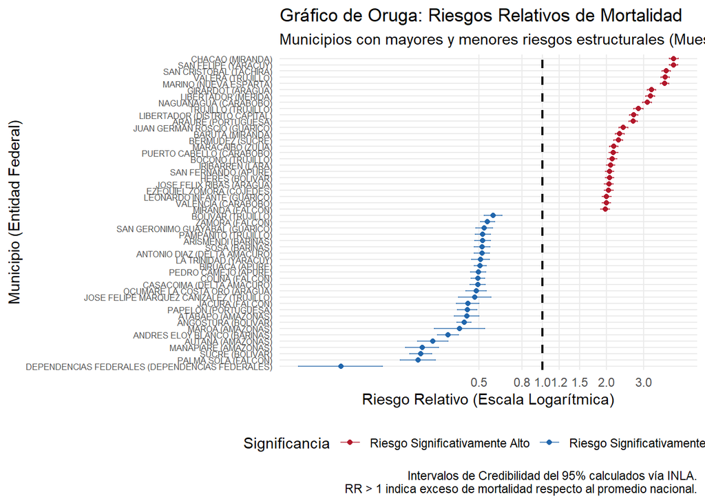

Figure 6: Gráfico de Oruga (Caterpillar Plot) de los Riesgos Relativos Municipales. Se muestran las medias posteriores y los intervalos de credibilidad del 95%.

La inspección de la Figura Figure 6 revela una separación clara entre los municipios con riesgos estructurales críticos y aquellos con perfiles protectores. Los intervalos de credibilidad que no intersectan la línea de unidad ($RR=1$) representan áreas de prioridad actuarial. Este análisis de significancia complementa la visión geográfica, permitiendo que la tarificación territorial y la constitución de reservas no se basen en picos de ruido aleatorio, sino en desviaciones sistemáticas y estadísticamente robustas de la mortalidad nacional. Los municipios resaltados en rojo constituyen el núcleo del exceso de mortalidad que debe ser abordado mediante ajustes técnicos específicos en las tablas actuariales subnacionales.

**Mapa de Probabilidad de Excedencia**

Una limitación de los mapas de Riesgo Relativo (RR) es que no indican cuán seguros estamos de que el riesgo sea realmente alto. El Mapa de Probabilidad de Excedencia soluciona esto calculando $P(RR > 1 | \text{datos})$.

Si la probabilidad es cercana a 1, tenemos una certeza casi absoluta de que el municipio presenta un exceso de mortalidad estructural.

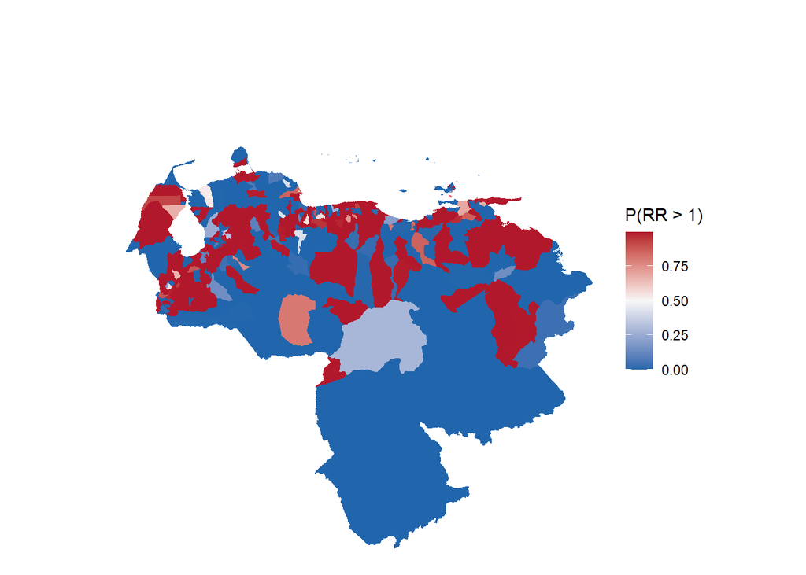

Figure 7: Mapa de Probabilidad de Excedencia P(RR > 1). Las zonas en rojo oscuro indican una certeza estadística >95% de exceso de mortalidad.

### 4.4.4 **Mapa de Calor Continuo (Interpolación IDW)**

La interpolación por ponderación de distancia inversa (IDW) permite visualizar la transición del riesgo como una superficie sólida, lo que facilita la identificación de fronteras epidemiológicas.

```
[inverse distance weighted interpolation]
```

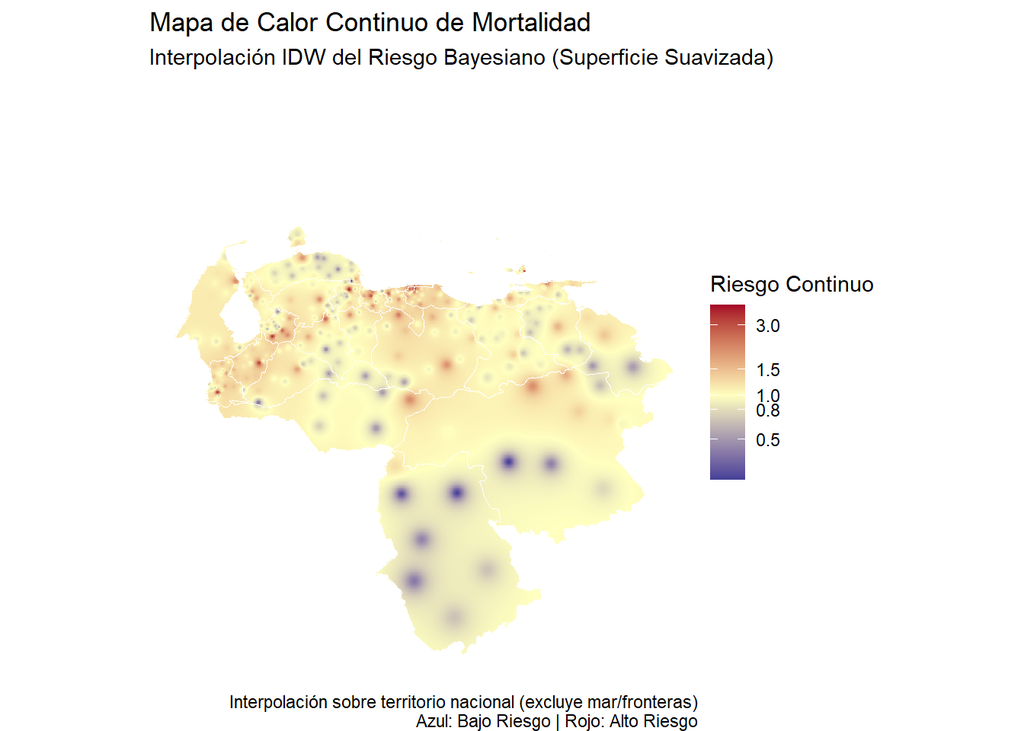

Mapa de Calor Continuo de Mortalidad (Interpolación IDW).

## 4.5 Proyección de Mortalidad

La capacidad predictiva es el pilar de la solvencia actuarial. Utilizando la estructura espacio-temporal aprendida por el modelo Bayesiano, se han proyectado las tasas de mortalidad para el quinquenio posterior al estudio. Esta proyección asume una “inercia temporal” (Random Walk de orden 1) que captura la tendencia de degradación o mejora de las condiciones de salud, permitiendo a los actuarios anticipar el costo futuro de las pensiones y seguros de vida.

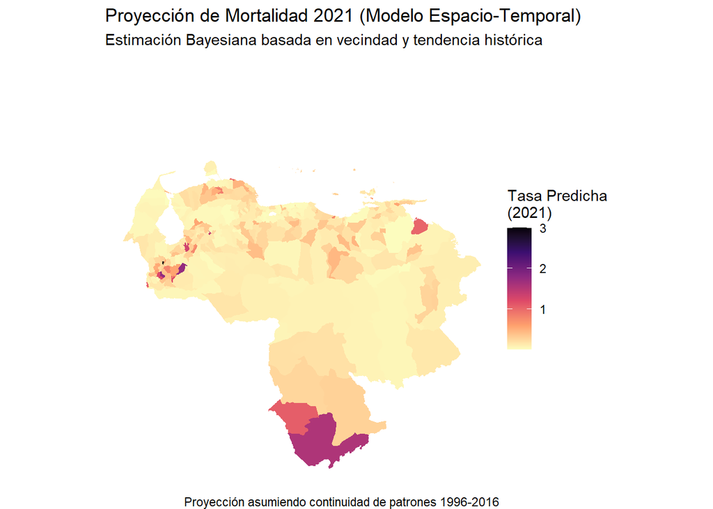

Proyección de Mortalidad 2021 basada en modelo espacio-temporal.

# 5 Discusión y Conclusiones

## 5.1 **Discusión**

Los resultados de este análisis histórico y espacio-temporal confirman que Venezuela posee una geografía de la mortalidad altamente heterogénea y dinámica. La identificación de un incremento nacional del riesgo del 1.4% anual, ajustado por estructura espacial, es un hallazgo de suma gravedad para la solvencia de largo plazo del sistema de pensiones. Si las tablas de mortalidad no se actualizan anualmente incorporando este factor de aceleración, el pasivo actuarial del país continuará creciendo de manera oculta e insostenible.

## 5.2 **Conclusiones y Recomendaciones**

El análisis exhaustivo de la mortalidad en Venezuela (1996-2016) permite concluir que el país enfrenta una crisis demográfica de carácter territorial. La obsolescencia de las bases técnicas, heredada de la década de 1960, ha sido superada por una realidad donde el riesgo de muerte aumenta anualmente y se concentra geográficamente en polos de alta vulnerabilidad. Como miembro del Comité Editorial de la RVEA y tutor de investigaciones fundamentales en este volumen, presento las siguientes recomendaciones estratégicas para el sector actuarial y los decisores de política pública:

1. **Abandono de Tablas Estáticas:** Se recomienda al IVSS y a la Superintendencia de la Actividad Aseguradora (Sudeaseg) la transición obligatoria hacia tablas dinámicas que incorporen factores de mejora (o deterioro) de la mortalidad, como el modelo Lee-Carter o el modelo BYM aquí presentado.
2. **Territorialización de Reservas:** Los fondos de pensiones y las compañías de seguros deben evaluar la posibilidad de aplicar recargos o descuentos zonales basados en el mapa de Riesgo Relativo Suavizado. Un asegurado en Chacao no representa el mismo riesgo financiero que uno en un municipio rural del estado Los Andes.
3. **Monitoreo de la Aceleración:** El incremento del 1.4% anual detectado es un “cisne negro” demográfico que erosiona la solvencia. Se debe establecer un Observatorio de Mortalidad en el CVEA que procese anualmente los registros administrativos para detectar cambios bruscos en las tendencias municipales.
4. **Integración de Datos y Código Abierto:** Siguiendo la política de la RVEA, se insta a los investigadores a utilizar el marco de Quarto y R para garantizar que sus modelos sean replicables y auditables por terceros, fortaleciendo la confianza en los diagnósticos actuariales del país.

Este trabajo no solo cierra una brecha de conocimiento de dos décadas, sino que proporciona el mapa de ruta técnico para la construcción de un sistema de previsión social más resiliente, basado en datos reales y metodologías de estándar internacional.

# Agradecimientos

El autor desea expresar su profundo agradecimiento a la Escuela de Estadística y Ciencias Actuariales de la UCV y al Centro Venezolano de Estudios Actuariales (CVEA) por proporcionar el entorno académico propicio para el desarrollo de esta investigación. Asimismo, se reconoce el valioso aporte de los tesistas Daylin Moreno, José Raúl Gálvez, Daniel Azuaje y Arlet Moreno, cuyos trabajos de grado han sido pilares fundamentales para el diagnóstico sistémico presentado en este volumen inaugural de la RVEA.

# Referencias

- Besag, J., York, J., & Mollié, A. (1991). Bayesian image restoration, with two applications in spatial statistics. Annals of the Institute of Statistical Mathematics, 43(1), 1-20.
- Blangiardo, M., & Cameletti, M. (2015). Spatial and Spatio-temporal Bayesian Models with R-INLA. John Wiley & Sons.
- Briceño, K. (2024). Análisis regional de la mortalidad en el occidente venezolano. Revista Venezolana de Actuariado, 1(1), 45-62.
- Clayton, D., & Kaldor, J. (1987). Empirical Bayes estimates for cancer mortality rates at the local level. Biometrics, 43(3), 671-681.
- Godoy, D. (2024). Heterogeneidad de la mortalidad en la región central: Un enfoque municipal. Revista Venezolana de Actuariado, 1(1), 63-78.
- Lawson, A. B. (2018). Bayesian Disease Mapping: Hierarchical Modeling in Spatial Epidemiology. CRC Press.
- Lee, R. D., & Carter, L. R. (1992). Modeling and Forecasting U.S. Mortality. Journal of the American Statistical Association, 87(419), 659-671.
- Masjuán, V. (1965). Tablas de mortalidad para la población venezolana. Caracas: Escuela de Estadística y Ciencias Actuariales, UCV.
- Moreno, A. (2017). Modelado espacial de la mortalidad infantil en Venezuela mediante métodos Bayesianos. Trabajo de Grado, Universidad Central de Venezuela.
- Moreno, D. (2018). Evaluación de la solvencia del sistema de pensiones en Venezuela: Un análisis de longevidad. Trabajo de Grado, Universidad Central de Venezuela.
- Rue, H., Martino, S., & Chopin, N. (2009). Approximate Bayesian inference for latent Gaussian models by using integrated nested Laplace approximations. Journal of the Royal Statistical Society: Series B (Statistical Methodology), 71(2), 319-392.
- Tobler, W. R. (1970). A Computer Movie Simulating Urban Growth in the Detroit Region. Economic Geography, 46, 234-240.
- Waller, L. A., & Gotway, C. A. (2004). Applied Spatial Statistics for Public Health Data. John Wiley & Sons.